# R Notebook

### 25.2.5 Exercises

##### 1.A linear trend seems to be slightly too simple for the overall trend. Can you do better with a quadratic polynomial? How can you interpret the coefficients of the quadratic? (Hint you might want to transform year so that it has mean zero.)

I will put both the simple linear model and the polynomial models into the data frame, map the residuals for both as in the text, and then facet on the models.

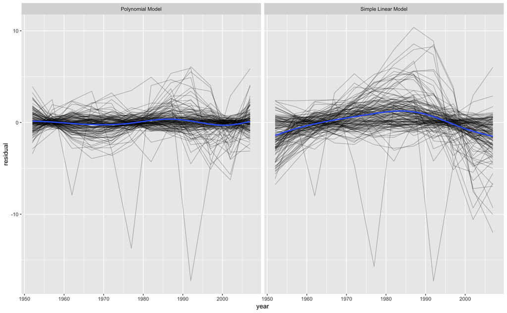

```r
library(tidyverse)
library(modelr)
library(gapminder)
by_country <- gapminder %>%
  group_by(country, continent) %>%
  nest()
country_model_1 <- function(df) {
  lm(lifeExp ~ year, data = df)
}
country_model_2 <- function(df) {
  lm(lifeExp ~ poly(year - mean(year), degree = 2), data = df)
}
models_1 <- map(by_country$data, country_model_1)
models_2 <- map(by_country$data, country_model_2)
by_country <- by_country %>%
  mutate(model_1 = map(data, country_model_1),
         model_2 = map(data, country_model_2))
by_country <- by_country %>%
  mutate(
    resids_1 = map2(data, models_1, add_residuals),
    resids_2 = map2(data, models_2, add_residuals)
  )
residuals <- unnest(by_country, resids_1, resids_2) %>% select(country:resid, resid1)
#As revealed by this bit of code, the construction here is a bit hack-ish
residuals <- residuals %>% gather(resid, resid1, key = "model", value = "residual") %>%
  mutate(model = ifelse(model == "resid", "Simple Linear Model", "Polynomial Model"))
residuals %>% ggplot(aes(x = year, y = residual)) + geom_line(aes(group = country), alpha = 1/4) +
  geom_smooth(se = FALSE) + facet_wrap(~ model)
```

We can also facet on both model and continent:

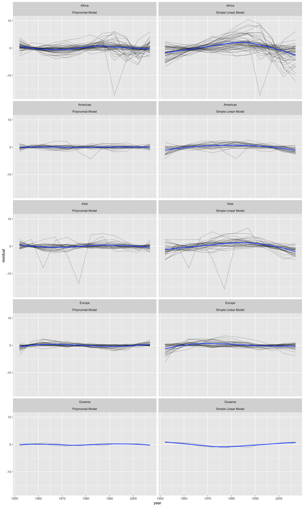

```r
residuals %>% ggplot(aes(x = year, y = residual)) + geom_line(aes(group = country), alpha = 1/4) +
  geom_smooth(se = FALSE) + facet_wrap(continent~ model, ncol = 2)
```

Now consider the quantitative comparison of the models, in terms of R-squared

[figure not shown]

Finding the countries for which r.squared is less than 0.125 in one or the other of the models:

```r
glance %>% filter(r.squared < 0.125)
```

| country | continent | model_name | r.squared | adj.r.squared | sigma | statistic | p.value | df | logLik | AIC | BIC | deviance | df.residual |
| --- | --- | --- | --- | --- | --- | --- | --- | --- | --- | --- | --- | --- | --- |
| Botswana | Africa | model_1 | 0.03402340 | -0.062574259 | 6.112177 | 0.35221765 | 0.5660414 | 2 | -37.65673 | 81.31346 | 82.76818 | 373.5871 | 10 |
| Lesotho | Africa | model_1 | 0.08485635 | -0.006658011 | 5.933934 | 0.92724627 | 0.3582864 | 2 | -37.30158 | 80.60316 | 82.05788 | 352.1157 | 10 |
| Rwanda | Africa | model_1 | 0.01715964 | -0.081124401 | 6.558269 | 0.17459230 | 0.6848927 | 2 | -38.50205 | 83.00411 | 84.45883 | 430.1090 | 10 |
| Swaziland | Africa | model_1 | 0.06821087 | -0.024968046 | 6.644091 | 0.73204189 | 0.4122530 | 2 | -38.65807 | 83.31614 | 84.77086 | 441.4395 | 10 |
| Zambia | Africa | model_1 | 0.05983644 | -0.034179918 | 4.528713 | 0.63644711 | 0.4435318 | 2 | -34.05859 | 74.11717 | 75.57189 | 205.0924 | 10 |
| Zimbabwe | Africa | model_1 | 0.05623196 | -0.038144842 | 7.205431 | 0.59582397 | 0.4580290 | 2 | -39.63135 | 85.26271 | 86.71743 | 519.1823 | 10 |
| Rwanda | Africa | model_2 | 0.01735115 | -0.201015261 | 6.912349 | 0.07945888 | 0.9242566 | 3 | -38.50089 | 85.00177 | 86.94140 | 430.0252 | 9 |

All of these countries display a mix of economic development (e.g. felicitous use of money from diamonds in Botswana) and tragedy (e.g. e.g. AIDS in Southern Africa and Genocide in Rwanda). The failure of both of the models for Rwanda is quite striking, and likely reflects the fact that both the genocide and the strong economic development that followed it went against the trends of other countries.